# Global Maternal Mortality and Gross Domestic Product (GDP) Per Capita Analysis (2019)

Data Analysis Report

2025-08-29

# Executive Summary

This report analyzes global maternal mortality ratios (MMR) and Gross Domestic Product (GDP) per capita for the year 2019. Using world map visualizations and correlation analysis, we examine the spatial distribution of these indicators and explore their relationship across countries.

# World Map Visualizations

## Maternal Mortality Ratio World Map

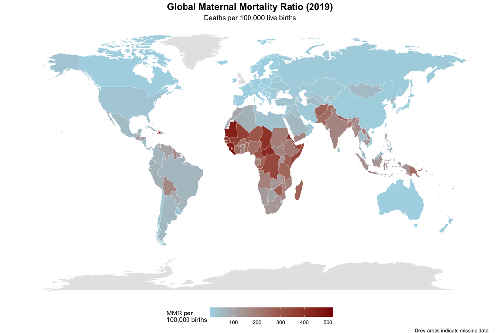

## GDP Per Capita World Map

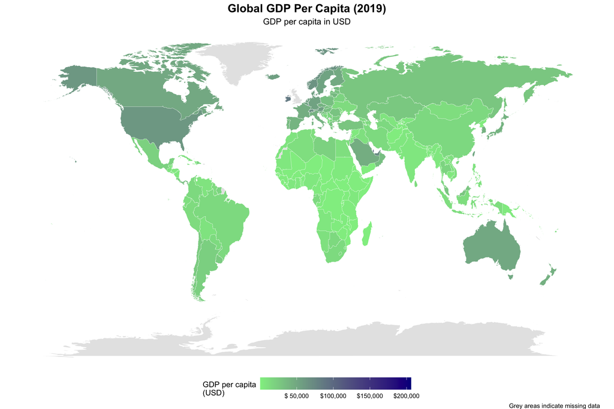

# Data Merging and Relationship Analysis

## Scatterplot: Maternal Mortality vs GDP Per Capita

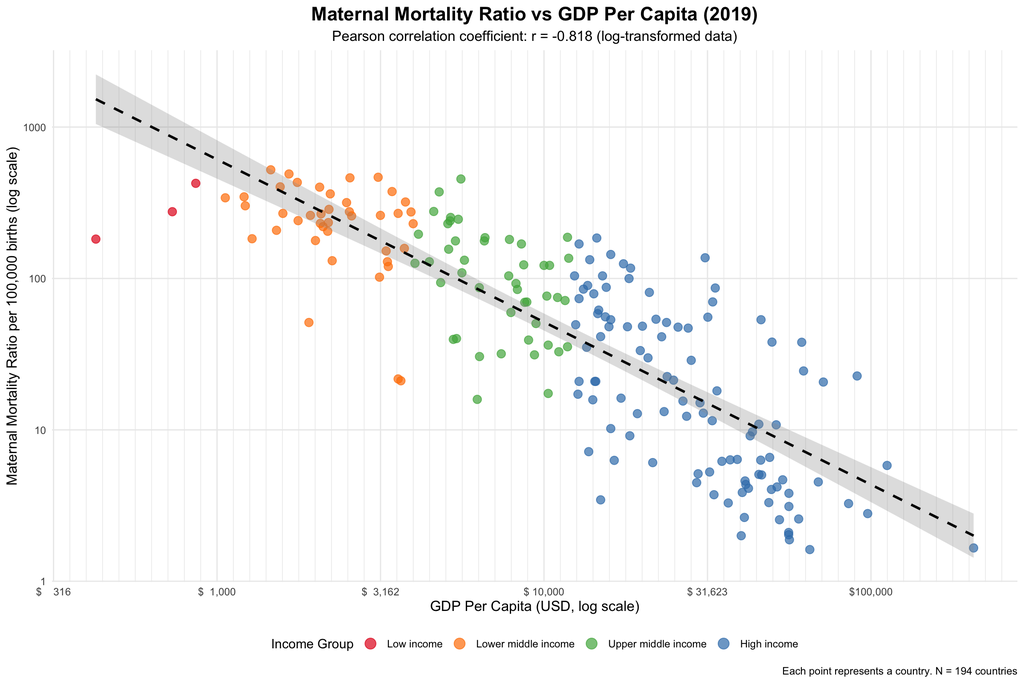

# Statistical Analysis and Interpretation

Correlation Analysis Results

| Data Type | Pearson r | P-value |
| --- | --- | --- |
| Raw data | -0.520 | 0 |
| Log-transformed data | -0.818 | 0 |

Countries with Highest and Lowest Maternal Mortality Ratios

| Country | MMR | GDP per capita (USD) | Income Group |
| --- | --- | --- | --- |
| Liberia | 522.00 | 1,460 | Lower middle income |
| Sierra Leone | 490.00 | 1,660 | Lower middle income |
| Haiti | 466.00 | 3,110 | Lower middle income |
| Guinea | 462.00 | 2,550 | Lower middle income |
| Mauritania | 454.00 | 5,570 | Upper middle income |
| Norway | 1.62 | 65,000 | High income |
| Monaco | 1.66 | 206,000 | High income |
| Andorra | 1.88 | 56,300 | High income |
| Cyprus | 2.00 | 40,100 | High income |
| Iceland | 2.03 | 56,000 | High income |

# Key Findings and Interpretation

## Relationship Interpretation

The scatterplot reveals a **strong negative relationship** between maternal mortality ratio and GDP per capita (r = -0.818 for log-transformed data, p < 0.001). This indicates that:

1. **Economic Development and Maternal Health**: Countries with higher economic development (measured by GDP per capita) tend to have significantly lower maternal mortality rates.
2. **Magnitude of Association**: The correlation coefficient of -0.818 represents a strong negative relationship, suggesting that approximately 66.9% of the variation in maternal mortality can be explained by GDP per capita.
3. **Income Group Patterns**: The data clearly shows distinct clustering by income groups:
   - **High-income countries** (blue points) cluster in the lower-right: high GDP, low MMR
   - **Low-income countries** (red points) cluster in the upper-left: low GDP, high MMR
   - **Middle-income countries** show intermediate patterns
4. **Global Health Equity**: The strong relationship highlights significant global health inequities, where economic resources are closely tied to maternal health outcomes.

## Geographic Patterns

The world maps reveal:

- **Regional Disparities**: Sub-Saharan Africa shows consistently high maternal mortality rates, while Europe, North America, and parts of Asia show low rates.
- **Economic Geography**: The GDP map shows similar patterns, with wealthy regions corresponding to areas with better maternal health outcomes.

## Policy Implications

The findings suggest that: - Economic development and healthcare investment are crucial for improving maternal health - Targeted interventions in lower-income countries could significantly reduce global maternal mortality - The relationship is strong enough to use economic indicators as proxies for maternal health system strength

# Conclusion

This analysis demonstrates a robust negative correlation between maternal mortality and economic development globally. The relationship is statistically significant and practically meaningful, suggesting that economic growth and targeted healthcare investments are essential strategies for reducing maternal mortality worldwide. The geographic visualization further emphasizes the global nature of this challenge and the need for international cooperation to address maternal health disparities.

## Personal Learning

Having had no experience using AI for data analysis, I am amazed by what it can be used to do. I can see the value of using it. I have some reservations about potential errors and the most efficient ways to identify them. For example, what are all of the potential errors that can be made when using AI in this way? Interpretation seems like an obvious one but what about data cleaning? I would want to have a good grasp on how to approach this to ensure my analyses were accurate before using it at work.